# Python

- 自学 Python 第九天
- 学习Matplotlib
- 本文参考了该[网址](https://www.icourse163.org/learn/BIT-1001870002?tid=1450349444#/learn/content?type=detail&id=1214619042&sm=1)
- Matplotlib是优秀的第三方数据可视化库
- Matplotlib.pyplot是绘制各种可视化图形的命令字库，相当于快捷键

```python
%matplotlib inline
import matplotlib.pyplot as plt
```

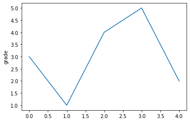

```python
plt.plot([3,1,4,5,2])
plt.ylabel("grade")
plt.savefig("test",dpi=600)#存储图片的命令，默认存储为png格式，dpi为图片输出的质量；
plt.show()
```

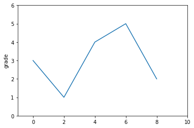

```python
plt.plot([0,2,4,6,8],[3,1,4,5,2])
plt.ylabel("grade")
plt.axis([-1,10,0,6])#横轴起始于-1，终止与10，纵轴起始于0，终止与6
plt.show()
```

pyplot的绘图区域：即在全局绘图区域中创建一个分区体系，并定位到一个字绘图区域。

- plt.subplot(nrows,ncols,plot_number)#nrows是number of row

```python
%matplotlib inline
import numpy as np
import matplotlib.pyplot as plt
```

```python
def f(t):
    return np.exp(-t)*np.cos(2*np.pi*t)
```

```python
a = np.arange(0.,5.,0.01)
```

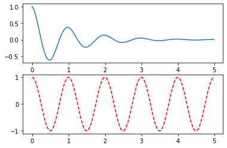

```python
plt.subplot(2,1,1)
plt.plot(a,f(a))
plt.subplot(2,1,2)
plt.plot(a,np.cos(2*np.pi*a),"r--")
plt.show()
```

`plt.plot(x,t,format_string,kwargs)`

- format_string 控制曲线的格式字符串,由颜色字符，风格字符和标记字符组成
- kwargs其它参数:color="",linestyle="",marker="",markerfacecolor=""(markerfacecolor是标记的颜色)，markersize=""
- kwargs中的设置也可以在format_string设置，效果都一样。

```python
import numpy as np
import matplotlib.pyplot as plt
```

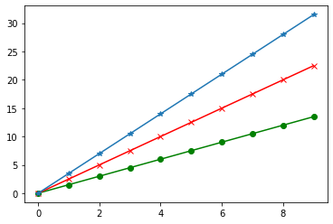

```python
a = np.arange(10)
plt.plot(a,a*1.5,'go-',a,a*2.5,'rx-',a,a*3.5,'*-')#绘制多条曲线
plt.show()
```

pyplot并不支持中文显示，第一种方式是需要rcParams修改字体实现

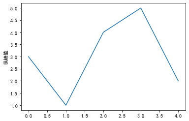

```python
import matplotlib
import matplotlib.pyplot as plt
matplotlib.rcParams["font.family"]="SimHei"#SimHei 是黑体
plt.plot([3,1,4,5,2])
plt.ylabel("纵轴值")
plt.show()
```

```python
import numpy as np
import matplotlib.pyplot as plt
import matplotlib
```

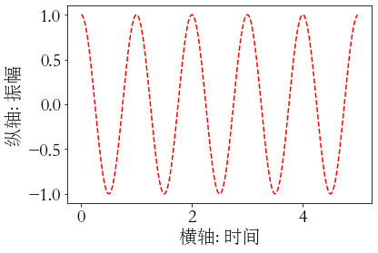

```python
matplotlib.rcParams["font.family"]="STSong"
matplotlib.rcParams["font.size"]=20
a = np.arange(0.,5.,0.01)
plt.xlabel("横轴: 时间")
plt.ylabel("纵轴: 振幅")
plt.plot(a,np.cos(2*np.pi*a),"r--")
plt.show()
```

pyplot显示中文的第二种方法，即在有中文出现的地方增加一个属性，fontproperties,而第一种方法改变了全局的效果，比如横轴上的数字也变大了，但这一种只改变你想改变的地方，其他不变，各有利弊吧。

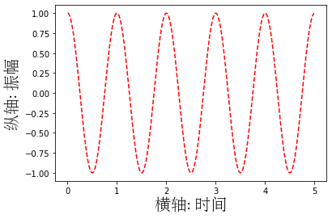

```python
import numpy as np
import matplotlib.pyplot as plt
a = np.arange(0.,5.,0.01)
plt.xlabel("横轴: 时间",fontproperties="STSong",fontsize=20)
plt.ylabel("纵轴: 振幅",fontproperties="STSong",fontsize=20)
plt.plot(a,np.cos(2*np.pi*a),"r--")
plt.show()
```

#### pyplot中文本显示函数

- plt.xlabel():对x轴增加文本标签
- plt.ylabel():对y轴增加文本标签
- plt.title():对图形整体增加文本标签
- plt.text():对任意位置增加文本
- plt.annotate():在图形中增加带箭头的注释

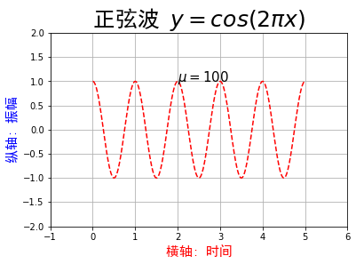

```python
import numpy as np
import matplotlib.pyplot as plt
a = np.arange(0.,5.,0.01)
plt.plot(a,np.cos(2*np.pi*a),"r--")

plt.xlabel("横轴: 时间",fontproperties="SimHei",fontsize=15,color="red")
plt.ylabel("纵轴: 振幅",fontproperties="SimHei",fontsize=15,color="blue")
plt.title(r"正弦波 $y=cos(2\pi x)$",fontproperties="SimHei",fontsize=25)
plt.text(2,1,r"$\mu=100$",fontsize=15)
plt.axis([-1,6,-2,2])
plt.grid(True)
plt.show()
```

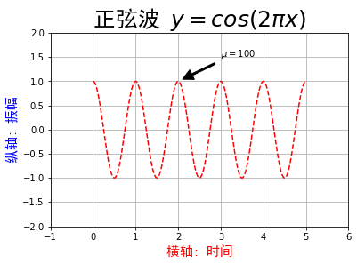

```python
import numpy as np
import matplotlib.pyplot as plt
a = np.arange(0.,5.,0.01)
plt.plot(a,np.cos(2*np.pi*a),"r--")

plt.xlabel("横轴: 时间",fontproperties="SimHei",fontsize=15,color="red")
plt.ylabel("纵轴: 振幅",fontproperties="SimHei",fontsize=15,color="blue")
plt.title(r"正弦波 $y=cos(2\pi x)$",fontproperties="SimHei",fontsize=25)
plt.annotate(r"$\mu=100$",xy=(2,1),xytext=(3,1.5),arrowprops=dict(facecolor="black",shrink=0.1,width=2))
plt.axis([-1,6,-2,2])
plt.grid(True)
plt.show()
##dict()是字典
```

### 绘制子图（plt.subplot（）只能绘制简单的子图）

plt.subplot2grid(Gridspace,CurSpace,colspan=1,rowspan=1),其理念是设定网格，选中网格，确定选中行列区域数量，编号从0开始

```python
import numpy as np
import matplotlib.pyplot as plt
```

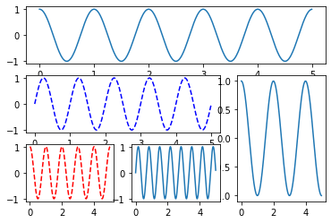

```python
a = np.arange(0.,5.,0.01)
plt.subplot2grid((3,3),(0,0),colspan=3)
plt.plot(a,np.cos(2*np.pi*a))
plt.subplot2grid((3,3),(1,0),colspan=2)
plt.plot(a,np.sin(2*np.pi*a),"b--")
plt.subplot2grid((3,3),(1,2),rowspan=2)
plt.plot(a,np.cos(1*np.pi*a))
plt.subplot2grid((3,3),(2,0))
plt.plot(a,np.cos(2*np.pi*a),"r--")
plt.subplot2grid((3,3),(2,1))
plt.plot(a,np.sin(3*np.pi*a))
plt.show()
```

```python
import matplotlib.gridspec as gridspec
```

### pyplot的基础函数

- plt.plot()
- plt.boxplot()：箱线图
- plt.bar():条形图
- plt.barh()：横向条形图
- plt.polar()：极坐标图
- plt.pie()：饼图
- plt.psd():绘制功率谱密度图
- plt.specgram():绘制谱图
- plt.choere(x,y):绘制相关性图
- plt.scatter():散点图
- plt.step()：绘制阶梯图
- plt.hist():直方图
- plt.contour():等高图
- plt.vlines():垂直图
- plt.stem():柴火图
- plt.plot_data():数据日期

```python
import matplotlib.pyplot as plt
```

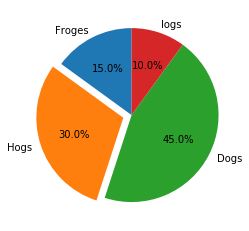

```python
labels="Froges","Hogs","Dogs","logs"
sizes=[15,30,45,10]
explode=(0,0.1,0,0)#第二个凸出来
plt.pie(sizes,explode=explode,labels=labels,autopct="%1.1f%%",startangle=90,shadow=False)
plt.show()
```

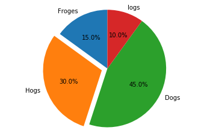

```python
labels="Froges","Hogs","Dogs","logs"
sizes=[15,30,45,10]
explode=(0,0.1,0,0)#第二个凸出来
plt.pie(sizes,explode=explode,labels=labels,autopct="%1.1f%%",startangle=90,shadow=False)
plt.axis("equal")
plt.show()
```

```python
import numpy as np
import matplotlib.pyplot as plt
```

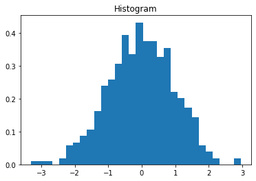

```python
mu,sigma=0,1
a=np.random.normal(mu,sigma,size=500)
plt.hist(a,bins=30,density=1)
plt.title("Histogram")
plt.show()
```

### 绘制引力波 [数据地址](https://python123.io/dv/grawave.html)

```python
import numpy as np
import matplotlib.pyplot as plt
from scipy.io import wavfile
```

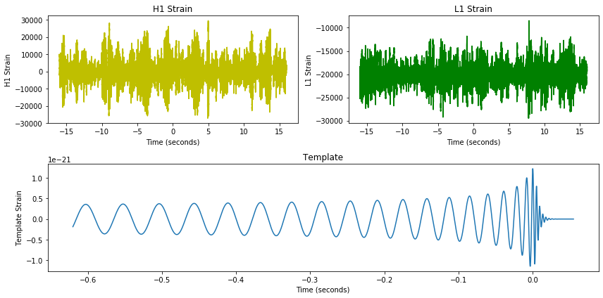

```python
import numpy as np
import matplotlib.pyplot as plt
from scipy.io import wavfile

rate_h, hstrain= wavfile.read(r"H1_Strain.wav","rb")
rate_l, lstrain= wavfile.read(r"L1_Strain.wav","rb")
#reftime, ref_H1 = np.genfromtxt('GW150914_4_NR_waveform_template.txt').transpose()
reftime, ref_H1 = np.genfromtxt('wf_template.txt').transpose() #使用python123.io下载文件

htime_interval = 1/rate_h
ltime_interval = 1/rate_l
fig = plt.figure(figsize=(12, 6))

# 丢失信号起始点
htime_len = hstrain.shape[0]/rate_h
htime = np.arange(-htime_len/2, htime_len/2 , htime_interval)
plth = fig.add_subplot(221)
plth.plot(htime, hstrain, 'y')
plth.set_xlabel('Time (seconds)')
plth.set_ylabel('H1 Strain')
plth.set_title('H1 Strain')

ltime_len = lstrain.shape[0]/rate_l
ltime = np.arange(-ltime_len/2, ltime_len/2 , ltime_interval)
pltl = fig.add_subplot(222)
pltl.plot(ltime, lstrain, 'g')
pltl.set_xlabel('Time (seconds)')
pltl.set_ylabel('L1 Strain')
pltl.set_title('L1 Strain')

pltref = fig.add_subplot(212)
pltref.plot(reftime, ref_H1)
pltref.set_xlabel('Time (seconds)')
pltref.set_ylabel('Template Strain')
pltref.set_title('Template')
fig.tight_layout()

#plt.savefig("Gravitational_Waves_Original.png")
plt.show()
plt.close(fig)
```